# Kiva Loan Usage Description Analysis

Team SAMI

May 25, 2018

# Text mining Kiva loan usage descriptions

The Kiva set has loans that are broadly defined by sector. However, these do not offer a lot of insight into what each loan is actually looking for outside of a generic label (such as retail). To enhance the company’s awareness of what specific uses people are taking loans for, this text mining activity seeks to shed light on the top words loan applications mention. This will be conducted by gender and by sector. This chunk allows direct access to the cloud platform our team created. I’ve elected to use the original csv for the analysis though, only because some of the loan usage data was stripped following cleaning.

```r
library(dplyr)
library(ggplot2)
library(tidytext)
library(RMySQL)
library(DBI)

#getSqlConnection <- function(){
  #con <-
    #dbConnect(
      #MySQL(),
      #username = 'root',
      #password = 'root',
      #host = '104.196.214.52')
  #return(con)
#}

#connection <- getSqlConnection()

#res <- dbListTables(connection)

kiva_loans <- read.csv("kiva_loans.csv", stringsAsFactors = F, na.strings = "")
```

To start, the text set is derived from the main kiva loans data. The focus here in on the use column as well as sector and borrower gender. However, some transformations need to take place first. Since borrower gender includes strings with a mix of men or women, a new field was created to mark loans that are for men, women, or a mixed group. These will be used to group text and see if there are any differences in loans taken on by men and women.

```r
text_set <- kiva_loans %>%
  select(activity, sector, use, borrower_genders) %>%
  mutate(borrower_genders = gsub("female", "women", borrower_genders, fixed = T))

women <- grepl("women", text_set$borrower_genders)

men <- grepl("male", text_set$borrower_genders)

mixed_gender <- grepl("male.*women|women*male", text_set$borrower_genders)

text_set <- text_set %>%
  mutate(transformed_gender = case_when(
    mixed_gender ~ "mixed",
    men ~ "men",
    women ~ "women")) %>%
  select(-borrower_genders)
```

With the proper set created, the actual text mining can take place. The essential goal for this portion is to separate each individual word from the use column and count them. Additionally, these counts are grouped by sector. This means that Kiva could use these to get an in-depth analysis of what words make up each sector category. These could serve as effective insights for creating more representative categories, marketing for specific loan drives (e.g. for water access or drinking water tools), and generally better understanding their loans. As a note, column stop words (such as the, to, but, and so on) and buy, sell, and purchase have been removed because they are included in almost every loan and as such, offer relatively little value.

```r
loan_words <- text_set %>%
  unnest_tokens(word, use) %>%
  count(sector, word, sort = TRUE) %>%
  anti_join(stop_words) %>%
  ungroup()

loan_words <- loan_words %>%
  filter(word != "purchase" & word != "buy" & word != "sell" & word != "pay")
```

## Words by Sector

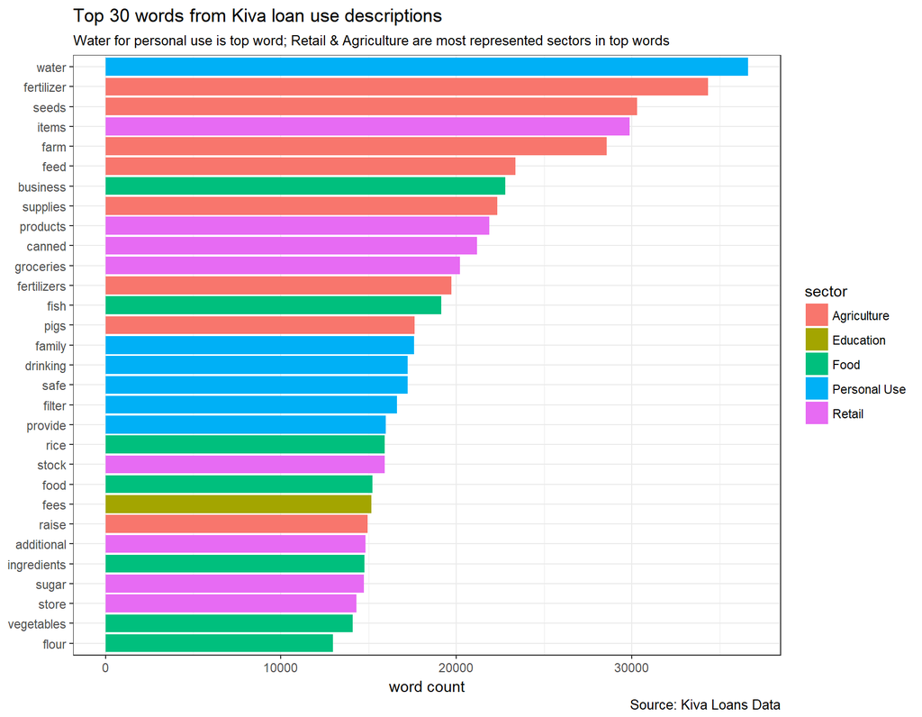

```r
theme_set(
  theme_bw()
)

loan_words %>%
  arrange(desc(n)) %>%
  slice(1:30) %>%
  mutate(word = reorder(word, n)) %>%
  ggplot(aes(word, n, fill = sector)) +
  geom_col() +
  coord_flip() +
  labs(title = "Top 30 words from Kiva loan use descriptions",
       subtitle = "Water for personal use is top word; Retail & Agriculture are most represented sectors in top words",
       x = NULL,
       y = "word count",
       caption = "Source: Kiva Loans Data")
```

Moving into all categories, the top 15 words from each sector are included. Most of the words fit nicely under the sector while adding nuance to each category. Again, these could be used to refine loan marketing to add more details for lenders to understand.

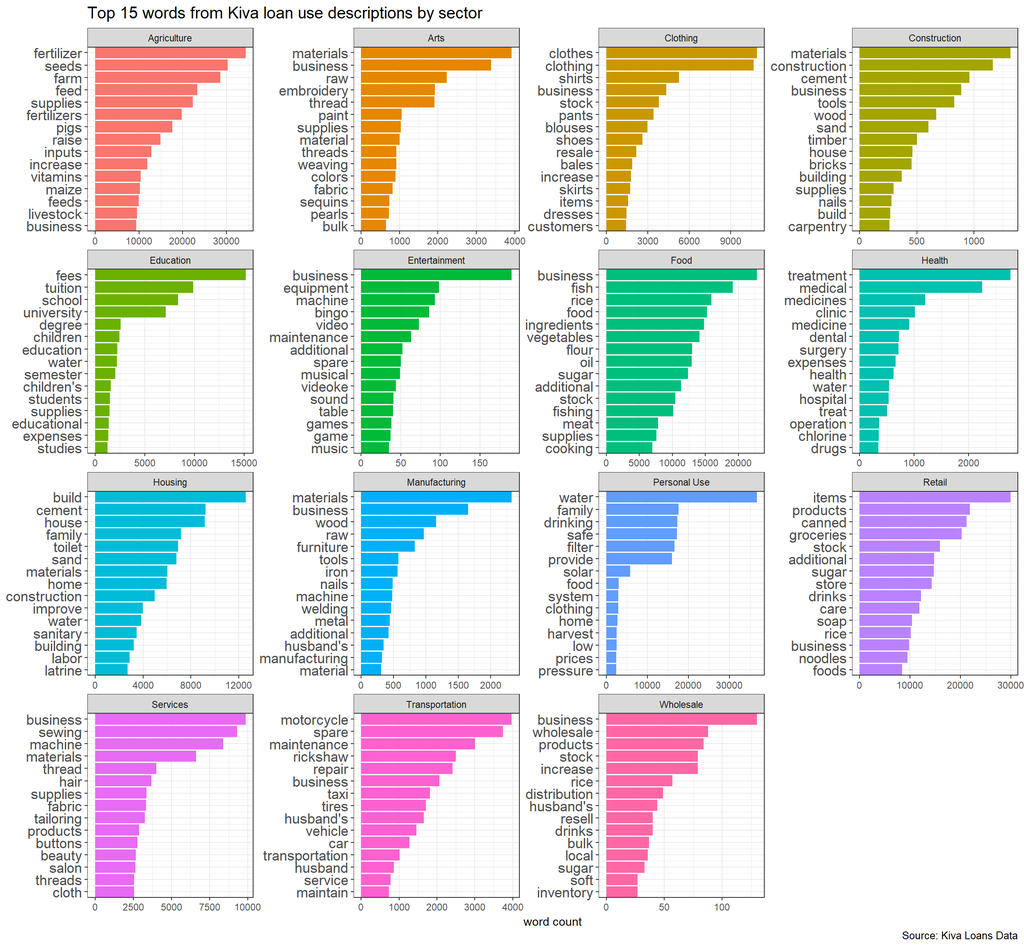

```r
loan_plot <- loan_words %>%
  group_by(sector) %>%
  top_n(15, n) %>%
  ungroup() %>%
  arrange(sector, n) %>%
  mutate(order = row_number())

loan_plot %>%
  ggplot(aes(order, n, fill = sector)) +
  geom_col(show.legend = FALSE) +
  facet_wrap(facets = "sector", scales = "free") +
  scale_x_continuous(breaks = loan_plot$order,
                     labels = loan_plot$word, expand = c(0, 0)) +
  coord_flip() +
  theme(plot.title = element_text(size = 15),
        axis.text.y =  element_text(size = 13)) +
  labs(title = "Top 15 words from Kiva loan use descriptions by sector",
       x = NULL,
       y = "word count",
       caption = "Source: Kiva Loans Data")
```

### Words by Gender

Kiva prides itself on helping disadvantaged peoples worldwide and has an added emphasis on women in particular. This text mining work will again help provide greater detail on the loan’s being taken out by women and what they’re used for. To do so, the words for gender are derived.

```r
gender_loans <- text_set %>%
  unnest_tokens(word, use) %>%
  count(transformed_gender, word, sort = TRUE) %>%
  anti_join(stop_words)%>%
  ungroup()

gender_loans <- gender_loans %>%
  filter(word != "purchase" & word != "buy" & word != "sell" & word != "pay")
```

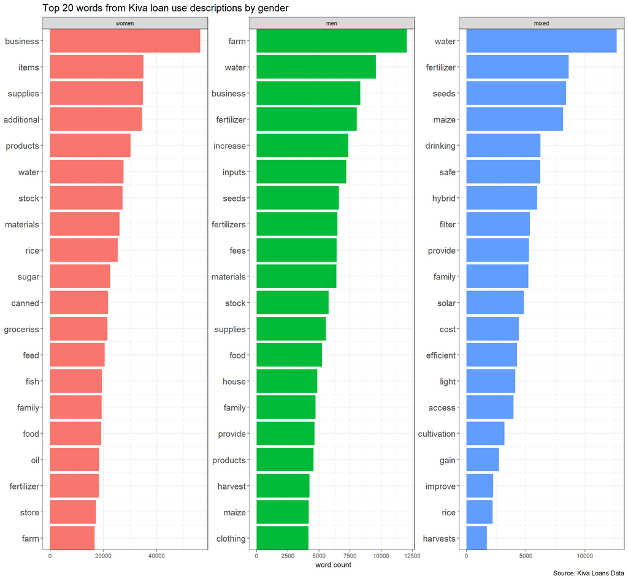

```r
gender_plot <- gender_loans %>%
  group_by(transformed_gender) %>%
  top_n(20, n) %>%
  ungroup() %>%
  arrange(transformed_gender, n) %>%
  mutate(order = row_number(),
         transformed_gender = factor(transformed_gender,
                                     levels = c("women", "men", "mixed")))

gender_plot %>%
  ggplot(aes(order, n, fill = transformed_gender)) +
  geom_col(show.legend = FALSE) +
  facet_wrap(facets = "transformed_gender", scales = "free") +
  coord_flip() +
  scale_x_continuous(breaks = gender_plot$order,
                     labels = gender_plot$word, expand = c(0, 0)) +
  theme(plot.title = element_text(size = 15),
        axis.text.y =  element_text(size = 13)) +
  labs(title = "Top 20 words from Kiva loan use descriptions by gender",
       x = NULL,
       y = "word count",
       caption = "Source: Kiva Loans Data")
```

Building on the previous insights, another set of word groupings was developed that accounted for both gender and sector. Specifically, the focus will be on common loan words for women by sector. This stems from what looked like a major focus on agriculture in the previous plot, something that was worth exploring in more detail.

```r
gender_sector <- text_set %>%
  unnest_tokens(word, use) %>%
  count(sector, transformed_gender, word, sort = TRUE) %>%
  anti_join(stop_words) %>%
  ungroup()

gender_sector <- gender_sector %>%
  filter(word != "purchase" & word != "buy" & word != "sell" & word != "pay") %>%
  filter(transformed_gender == "women")
```

The initial hunch appears reasonable with a large number of agriculture and retail words. This plot would provide Kiva with ample opportunity to tailor their product offerings or building compelling marketing case studies.

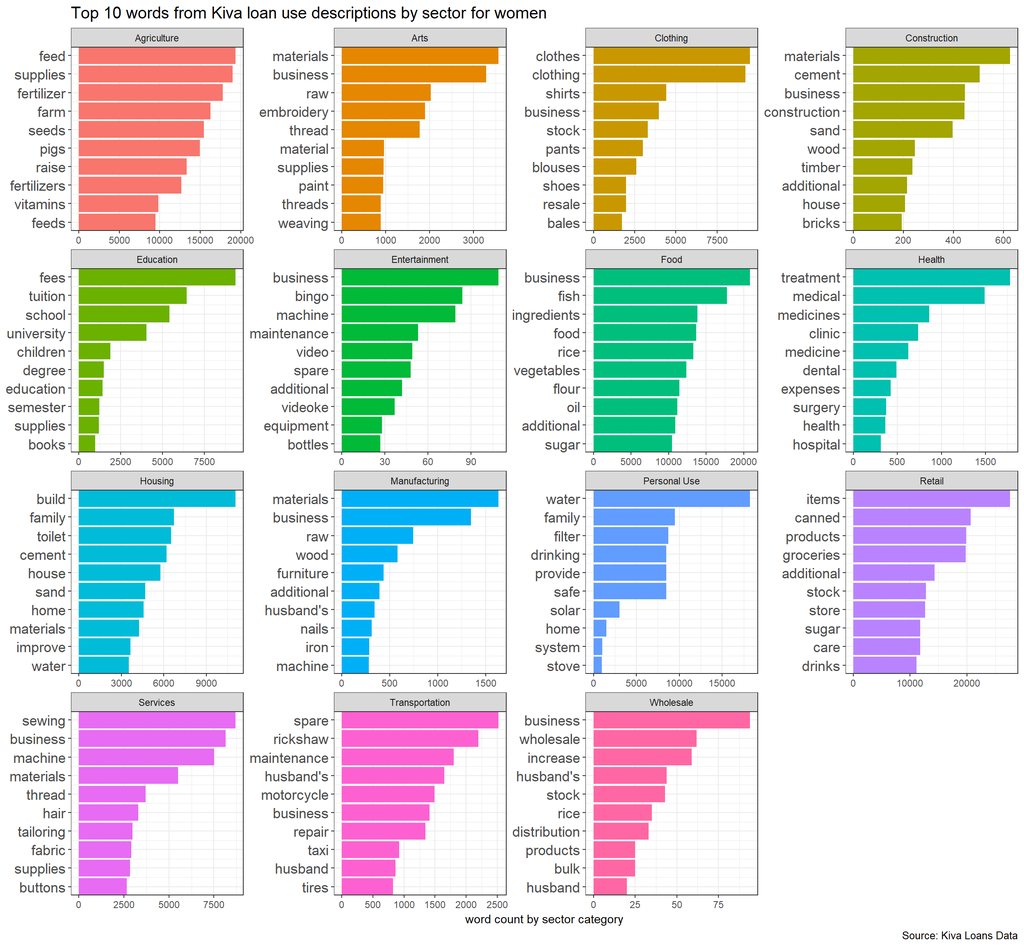

```r
women_plot <- gender_sector %>%
  group_by(sector) %>%
  top_n(10, n) %>%
  ungroup() %>%
  arrange(sector, n) %>%
  mutate(order = row_number())

women_plot %>%
  ggplot(aes(order, n, fill = sector)) +
  geom_col(show.legend = FALSE) +
  facet_wrap(facets = "sector", scales = "free") +
  scale_x_continuous(breaks = women_plot$order,
                     labels = women_plot$word, expand = c(0, 0)) +
  coord_flip() +
  theme(plot.title = element_text(size = 15),
        axis.text.y =  element_text(size = 13)) +
  labs(title = "Top 10 words from Kiva loan use descriptions by sector for women",
       x = NULL,
       y = "word count by sector category",
       caption = "Source: Kiva Loans Data")
```